# chapter 6 Memorization methods

N Anil Kumar

The `runif()` function in R generates random numbers from a uniform distribution. By default, it generates numbers between 0 and 1. Here’s what `runif(10)` does:

- It generates **10 random numbers** uniformly distributed between **0 and 1**.

For example, running `runif(10)` might produce output like this:

##### R

`[1] 0.123456 0.789012 0.345678 0.901234 0.567890 0.234567 0.890123 0.456789 0.678901 0.123890`

If you’d like to specify a different range, you can use the `min` and `max` arguments. For instance:

##### R

`runif(10, min = 50, max = 100)`

This will generate 10 random numbers between 50 and 100.

```r
runif(10)
```

```
##  [1] 0.02237457 0.75792217 0.76592832 0.89546898 0.68782615 0.86152410
##  [7] 0.36869208 0.44391737 0.26784668 0.18703206
```

```r
dataset<-c(1,4,5,6,7,8,9,9,0,3)
length(dataset)
```

```
## [1] 10
```

```r
set.seed(123)  # for reproducibility
dataset <- c(1,4,5,6,7,8,9,9,0,3)

# Generate random uniform numbers between 0 and 1 for each element
random_numbers <- runif(length(dataset))

# Assign to train if the random number < 0.7, else test
train <- dataset[random_numbers < 0.7]
test <- dataset[random_numbers >= 0.7]

train
```

```
## [1] 1 5 8 9 0 3
```

```r
test
```

```
## [1] 4 6 7 9
```

```r
a=rbinom(n=length(dataset),size=1,prob=0.1)
a
```

```
##  [1] 1 0 0 0 0 0 0 0 0 1
```

```r
useForCalRep <- a>0
useForCalRep
```

```
##  [1]  TRUE FALSE FALSE FALSE FALSE FALSE FALSE FALSE FALSE  TRUE
```

```r
dataset[useForCalRep]
```

```
## [1] 1 3
```

```r
table(va=c(1,2,2,1,1),a=c(1,1,1,1,1))
```

```
##    a
## va  1
##   1 3
##   2 2
```

```r
# Create a vector of colors
colors <- c("Red", "Blue", "Green", "Red", "Blue", "Red", "Yellow", "Green")

# Create a frequency table
color_table <- table(colors)

# Display the table
print(color_table)
```

```
## colors
##   Blue  Green    Red Yellow
##      2      2      3      1
```

```r
# Create a data frame
data <- data.frame(
  Gender = c("Male", "Female", "Male", "Female", "Male"),
  City = c("New York", "London", "New York", "Paris", "London")
)

# Create a two-way cross-tabulation
gender_city_table <- table(data$Gender, data$City)

# Display the table
print(gender_city_table)
```

```
##
##          London New York Paris
##   Female      1        0     1
##   Male        1        2     0
```

```r
print(gender_city_table[1])
```

```
## [1] 1
```

```r
library(ROCR)

predcol <- c(0.9, 0.8, 0.4, 0.2, 0.1)   # predicted probs
outcol <- c("Yes", "Yes", "No", "No", "Yes")
pos <- "Yes"

perf <- performance(prediction(predcol, outcol==pos), "auc")

print(class(perf))
```

```
## [1] "performance"
## attr(,"package")
## [1] "ROCR"
```

```r
print("---------------------")
```

```
## [1] "---------------------"
```

```r
print(perf@y.values)        # raw list
```

```
## [[1]]
## [1] 0.6666667
```

```r
print("---------------------")
```

```
## [1] "---------------------"
```

```r
print(as.numeric(perf@y.values))  # numeric AUC
```

```
## [1] 0.6666667
```

```r
#paste(dir,'orange_small_train.data.gz',sep='')
```

### In the Orange Dataset (KDD Cup 2009):

- **Churn** = customers leaving the company.
- **Appetency** = likelihood of customer responding positively to a marketing offer.
- **Upselling** = likelihood of customer purchasing a higher-end product/service.

```r
dir = "/home/anil/Downloads/"
file=paste(dir,'orange_small_train.data.gz',sep='')
print(file)
```

```
## [1] "/home/anil/Downloads/orange_small_train.data.gz"
```

```r
d <- read.table(file, header=T, sep='\t',
                  na.strings=c('NA',''))
#Treat both NA and the empty string as missing data.
#Read the file of independent variables. All data from
#https://github.com/WinVector/zmPDSwR/tree/master/KDD2009.
churn <- read.table(paste(dir,'orange_small_train_churn.labels.txt',sep=''),
                    header=F,sep='\t')
d$churn <- churn$V1
#Read churn dependent variable.
#Add churn as a new column.
appetency <- read.table(paste(dir,'orange_small_train_appetency.labels.txt',
                              sep=''),header=F,sep='\t')
d$appetency <- appetency$V1
#Add appetency as a new column.
upselling <- read.table(paste(dir,'orange_small_train_upselling.labels.txt',
                              sep=''),  header=F,sep='\t')
d$upselling <- upselling$V1
old_df<-d
```

```r
#### this is little difficult code ################
outcomes=c('churn','appetency','upselling')
random_rows <- old_df[sample(nrow(old_df), 100), c( 'Var192', 'Var193', 'Var216','Var218',outcomes)]
#d<-random_rows
set.seed(729375)
class(dim(d)[1])
```

```
## [1] "integer"
```

```r
class(dim(d)[[1]])
```

```
## [1] "integer"
```

```r
runif(10)
```

```
##  [1] 0.17014846 0.39475355 0.79740956 0.24310053 0.42252919 0.40654267
##  [7] 0.92001720 0.76619206 0.05897214 0.74713546
```

```r
d$rgroup <- runif(dim(d)[1])
dTrainAll <- subset(d,rgroup<=0.9)
#By setting the seed to the pseudo-random number generator, we make our
#work reproducible: someone redoing it will see the exact same results.
dTest <- subset(d,rgroup>0.9)

#Split data into train and test subsets.
vars <- setdiff(colnames(dTrainAll), c(outcomes,'rgroup'))
catVars <- vars[sapply(dTrainAll[,vars],class) %in%
#Identify which features are categorical variables.
c('factor','character')]
#Choose which outcome to model (churn).
#Choose which outcome is considered positive.
numericVars <- vars[sapply(dTrainAll[,vars],class) %in%
c('numeric','integer')]
#rm(list=c('d','churn','appetency','upselling'))
outcome <- 'churn'
#Identify which features are numeric variables.

#Remove unneeded objects from workspace.
pos <- '1'
useForCal <- rbinom(n=dim(dTrainAll)[[1]],size=1,prob=0.1)>0
dCal <- subset(dTrainAll,useForCal)
dTrain <- subset(dTrainAll,!useForCal)
```

The rbinom function in R is used to generate random numbers from a binomial distribution. This function is particularly useful for simulating the outcome of a series of Bernoulli trials, such as flipping coins or quality control in manufacturing.

The syntax for rbinom is:

rbinom(n, size, prob)

- n: Number of observations.
- size: Number of trials per observation.
- prob: Probability of success on each trial.

Examples

- Single Bernoulli Trial:

### Simulate the outcome of 10 coin flips

rbinom(10, 1, 0.5)

### Output: [1] 1 0 1 1 1 0 0 0 0 1

- Multiple Trials:

### Simulate the outcome of flipping 100 coins, repeated 10 times

rbinom(10, 100, 0.5)

### Output: [1] 52 55 51 50 46 42 50 49 46 56

```r
runif(10)
```

```
##  [1] 0.4551946 0.6319897 0.4226689 0.4135828 0.2826317 0.3312897 0.2412824
##  [8] 0.6846372 0.5757710 0.2996040
```

```r
# Define the positive class
pos <- "yes"

# Define the mkPredC function
mkPredC <- function(outCol, varCol, appCol) {
  # Base positive rate
  pPos <- sum(outCol == pos) / length(outCol)
  print(paste("Base positive rate (P(yes)) =", round(pPos,3)))

  # Probability if varCol is missing
  naTab <- table(as.factor(outCol[is.na(varCol)]))
  pPosWna <- (naTab/sum(naTab))[pos]
  print(paste("Probability of yes given varCol=NA =", round(pPosWna,3)))

  # Conditional counts table
  vTab <- table(as.factor(outCol), varCol)
  print("Contingency Table (outcome vs varCol):")
  print(vTab)

  # Conditional probability with smoothing
  pPosWv <- (vTab[pos,] + 1.0e-3*pPos) / (colSums(vTab) + 1.0e-3)
  print("Conditional probability P(yes|varCol):")
  print(round(pPosWv,3))

  # Predictions for application column
  pred <- pPosWv[appCol]
  print(" before handling missing values pred vector is")
  print(pred)
  print("pPosWv is")
  print(pPosWv)
  # Handle missing or unseen values
  pred[is.na(appCol)] <- pPosWna
  print("after pred[is.na(appCol)] <- pPosWna")
  print(pred)
  pred[is.na(pred)] <- pPos

  print("Final Predictions for appCol:")
  print(pred)
  return(pred)
}

# ------------------- SAMPLE DATA -------------------
outCol <- c("yes","no","yes","no","yes","no","no","yes")#, "yes")
varCol <- c("A","A","B","B","C","C",NA,"A")#,NA)
appCol <- c("A","B","C","D",NA)

# Run the function
preds <- mkPredC(outCol, varCol, appCol)
```

```
## [1] "Base positive rate (P(yes)) = 0.5"
## [1] "Probability of yes given varCol=NA = NA"
## [1] "Contingency Table (outcome vs varCol):"
##      varCol
##       A B C
##   no  1 1 1
##   yes 2 1 1
## [1] "Conditional probability P(yes|varCol):"
##     A     B     C
## 0.667 0.500 0.500
## [1] " before handling missing values pred vector is"
##         A         B         C      <NA>      <NA>
## 0.6666111 0.5000000 0.5000000        NA        NA
## [1] "pPosWv is"
##         A         B         C
## 0.6666111 0.5000000 0.5000000
## [1] "after pred[is.na(appCol)] <- pPosWna"
##         A         B         C      <NA>      <NA>
## 0.6666111 0.5000000 0.5000000        NA        NA
## [1] "Final Predictions for appCol:"
##         A         B         C      <NA>      <NA>
## 0.6666111 0.5000000 0.5000000 0.5000000 0.5000000
```

```r
# Show final predictions
print("Predicted probabilities for appCol:")
```

```
## [1] "Predicted probabilities for appCol:"
```

```r
print(preds)
```

```
##         A         B         C      <NA>      <NA>
## 0.6666111 0.5000000 0.5000000 0.5000000 0.5000000
```

```r
logLikelyhood <-function(outCol,predCol) {
  print(outCol==pos)
  print(predCol)
sum(ifelse(outCol==pos,log(predCol),log(1-predCol)))
}

logLikelyhood(outCol,preds)
```

```
## [1]  TRUE FALSE  TRUE FALSE  TRUE FALSE FALSE  TRUE
##         A         B         C      <NA>      <NA>
## 0.6666111 0.5000000 0.5000000 0.5000000 0.5000000
```

```
## [1] -5.662877
```

```r
# Install and load the rpart package if not already installed
# install.packages("rpart")
library(rpart)

# Load a sample dataset (e.g., Iris dataset)
data(iris)
i1=subset(iris,Species!="setosa")
print(i1)
```

[output not shown]

[output cut: 86 more lines]

```r
# Build a classification tree to predict Species based on other features
tree_model <- rpart(Species ~ ., data = i1, method = "class")

# Print the tree structure
print(tree_model)
```

```
## n= 100
##
## node), split, n, loss, yval, (yprob)
##       * denotes terminal node
##
## 1) root 100 50 versicolor (0.00000000 0.50000000 0.50000000)
##   2) Petal.Width< 1.75 54  5 versicolor (0.00000000 0.90740741 0.09259259) *
##   3) Petal.Width>=1.75 46  1 virginica (0.00000000 0.02173913 0.97826087) *
```

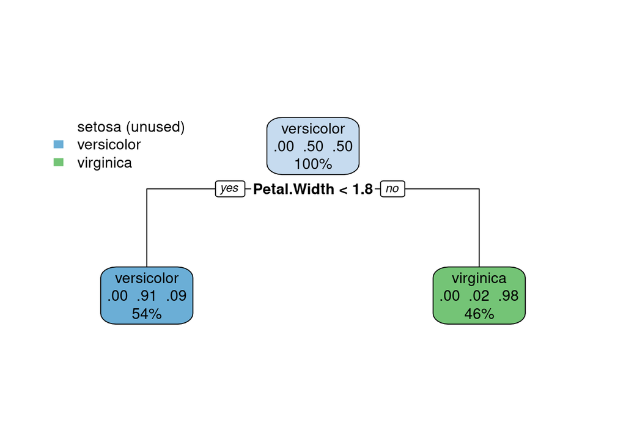

```r
# Plot the tree (requires rpart.plot package)
# install.packages("rpart.plot")
library(rpart.plot)
rpart.plot(tree_model)
```

```r
logLikelyhood <-
function(outCol,predCol) {
sum(ifelse(outCol==pos,log(predCol),log(1-predCol)))
}
```

```r
dTrain_set<-head(dTrain,10)
colnames(dTrain_set)
```

```
##   [1] "Var1"      "Var2"      "Var3"      "Var4"      "Var5"      "Var6"
##   [7] "Var7"      "Var8"      "Var9"      "Var10"     "Var11"     "Var12"
##  [13] "Var13"     "Var14"     "Var15"     "Var16"     "Var17"     "Var18"
##  [19] "Var19"     "Var20"     "Var21"     "Var22"     "Var23"     "Var24"
##  [25] "Var25"     "Var26"     "Var27"     "Var28"     "Var29"     "Var30"
##  [31] "Var31"     "Var32"     "Var33"     "Var34"     "Var35"     "Var36"
##  [37] "Var37"     "Var38"     "Var39"     "Var40"     "Var41"     "Var42"
##  [43] "Var43"     "Var44"     "Var45"     "Var46"     "Var47"     "Var48"
##  [49] "Var49"     "Var50"     "Var51"     "Var52"     "Var53"     "Var54"
##  [55] "Var55"     "Var56"     "Var57"     "Var58"     "Var59"     "Var60"
##  [61] "Var61"     "Var62"     "Var63"     "Var64"     "Var65"     "Var66"
##  [67] "Var67"     "Var68"     "Var69"     "Var70"     "Var71"     "Var72"
##  [73] "Var73"     "Var74"     "Var75"     "Var76"     "Var77"     "Var78"
##  [79] "Var79"     "Var80"     "Var81"     "Var82"     "Var83"     "Var84"
##  [85] "Var85"     "Var86"     "Var87"     "Var88"     "Var89"     "Var90"
```

[output cut: 24 more lines]

```r
dTrain_set<-subset(dTrain_set,select = c(Var222,Var223,churn))
```

```r
unique(dTrain_set$Var222)
```

```
##  [1] "fXVEsaq" "2Kb5FSF" "NKv4yOc" "CE7uk3u" "1J2cvxe" "R2LdzOv" "K2SqEo9"
##  [8] "EPqQcw6" "catzS2D" "VWtIBQt"
```

```r
unique(dTrain_set$Var223)
```

```
## [1] "jySVZNlOJy" "LM8l689qOp" NA
```

```r
sum(dTrain_set$predVar223)
```

```
## [1] 0
```

```r
#print(varCol)
a=seq(0,1,0.2)
varCol1=c(1,2,34,56,3,23,43,NA)
cat(varCol1)
```

```
## 1 2 34 56 3 23 43 NA
```

```r
print("cuts")
```

```
## [1] "cuts"
```

```r
cuts<-unique(as.numeric(quantile(varCol1,probs=a,na.rm=T)))
print(cuts)
```

```
## [1]  1.0  2.2 11.0 29.6 41.2 56.0
```

```r
print("output of seq(0,1,0.1) ")
```

```
## [1] "output of seq(0,1,0.1) "
```

```r
print(a)
```

```
## [1] 0.0 0.2 0.4 0.6 0.8 1.0
```

```r
print("quantile(varCol1,probs=seq(0, 1, 0.1),na.rm=T)")
```

```
## [1] "quantile(varCol1,probs=seq(0, 1, 0.1),na.rm=T)"
```

```r
quantile(varCol1,probs=a,na.rm=T)
```

```
##   0%  20%  40%  60%  80% 100%
##  1.0  2.2 11.0 29.6 41.2 56.0
```

```r
print("cut(varCol1,cuts)")
```

```
## [1] "cut(varCol1,cuts)"
```

```r
varC <- cut(varCol1,cuts)
print(varC)
```

```
## [1] <NA>        (1,2.2]     (29.6,41.2] (41.2,56]   (2.2,11]    (11,29.6]
## [7] (41.2,56]   <NA>
## Levels: (1,2.2] (2.2,11] (11,29.6] (29.6,41.2] (41.2,56]
```

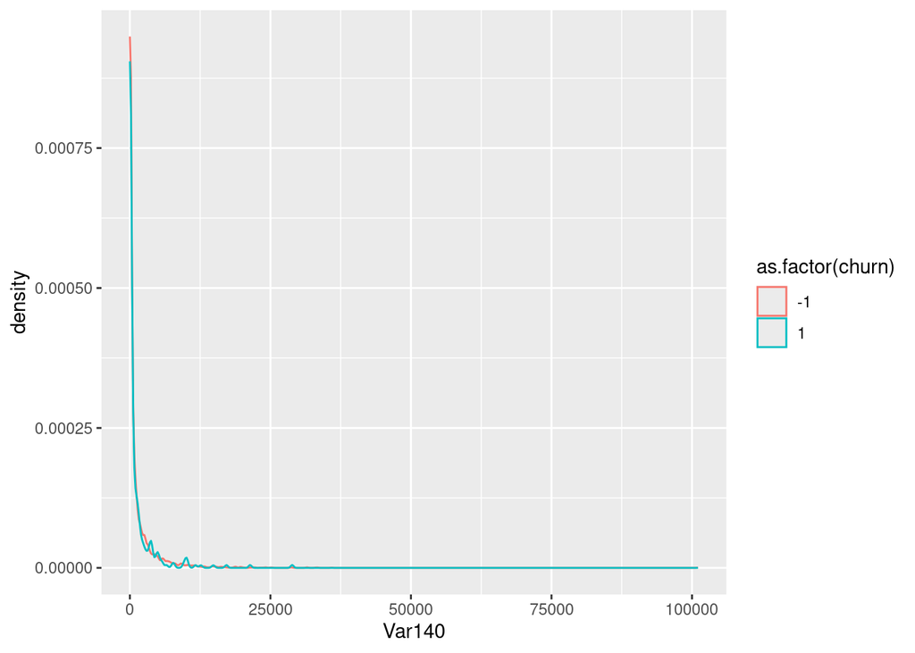

```r
library(ggplot2)
ggplot(data=dCal) +
geom_density(aes(x=Var140,color=as.factor(churn)))
```